# My visual data story: Phone Usage Behaviour

## What’s going on with this data?

This study seeks to understand the duration, purposes, and behavioral patterns of mobile phone usage at different times of the day.

## How much do people use their phones?

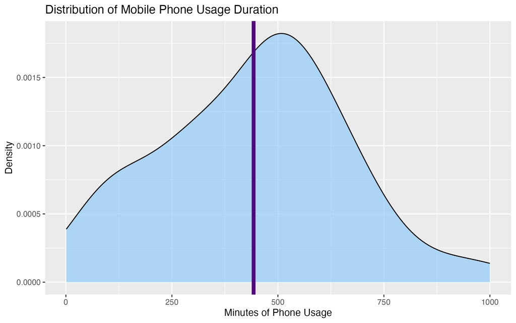

plot1

This distribution chart shows that the peak is around 500 minutes, indicating that the usage duration of most users is concentrated at this level; the purple reference line is at **442.7** minutes, slightly below the peak. The data is primarily concentrated in the 250–750 minute range, with density dropping rapidly beyond 750 minutes. This indicates that only a small number of users exceed 12 hours of usage. Overall, the data reflects that the average daily mobile phone usage among the students we surveyed is generally heavy, though there are a few outliers with exceptionally long usage times.

## Does purpose affect phone usage?

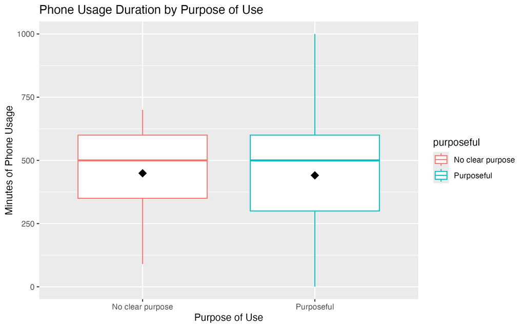

plot2

Comparison of the distribution of daily mobile phone usage between users with a **clear purpose** and those with **No a clear purpose**. We found that the median for both groups was around 500 minutes. The means (black diamond points) for the two groups are also very close; the Purposeful group is slightly lower, but the difference is minimal. Based on the mean and median values, the conclusion that there is a difference between users with and without a clear purpose does not appear to hold up clearly in the graph.

## What does timestamp data reveal?

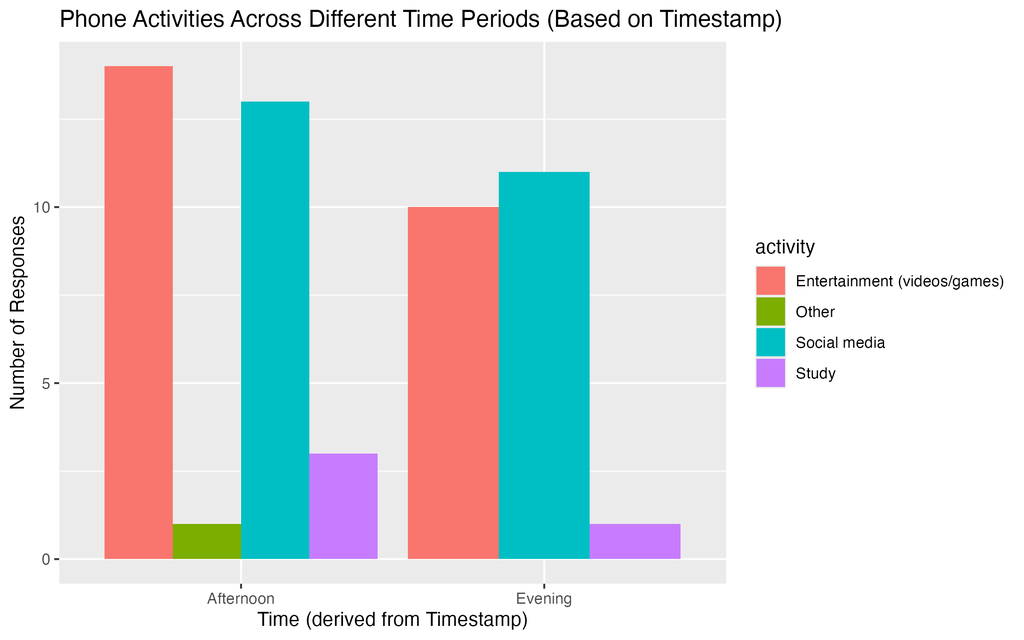

plot3

This visualization was generated using timestamp data from Google Forms responses. The chart illustrates the occurrence of various mobile activities during these time periods. Since the data is derived directly from timestamps, it reflects the actual submission times recorded in the dataset. This provides a more objective representation of behavioral patterns over time.

## How do participants describe their own phone habits?

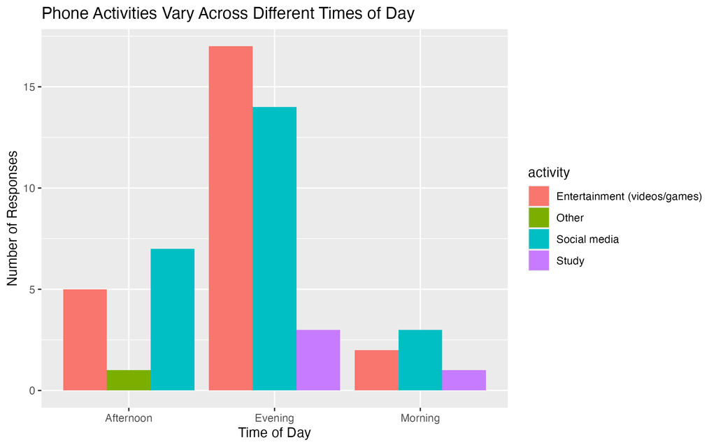

Unlike the previous visualizations, this chart is based on participants’ self-reported answers regarding the times of day when they believe they use their phones most frequently. Comparing these subjective responses with timestamp-based data highlights how people interpret and describe their own digital habits.